# Part I - Loan Data from Prosper

## Introduction

> This data set contains details of 113,937 loans with 81 variables on each loan, including loan amount, borrower rate (or interest rate), current loan status, borrower income, borrower employment status, borrower credit history, and the latest payment information.

## Preliminary Wrangling

```python
# import all packages and set plots to be embedded inline
import numpy as np
import pandas as pd
import matplotlib.pyplot as plt
import seaborn as sb

%matplotlib inline
```

## Data Gathering and Investigation

### In this section, I will be loading my data into pandas dataframe and employing various libraries to investigate the characteristics of the dataset before commencing exploration.

```python
## Loading the dataset
Loan_data = pd.read_csv("/Users/USER/Downloads/prosperLoanData.csv")

## Viewing the first 5 rows to confirm success of loading
Loan_data.head()

## Viewing general information about the dataset
Loan_data.info()
```

```
<class 'pandas.core.frame.DataFrame'>
RangeIndex: 113937 entries, 0 to 113936
Data columns (total 81 columns):
 #   Column                               Non-Null Count   Dtype
---  ------                               --------------   -----
 0   ListingKey                           113937 non-null  object
 1   ListingNumber                        113937 non-null  int64
 2   ListingCreationDate                  113937 non-null  object
 3   CreditGrade                          28953 non-null   object
 4   Term                                 113937 non-null  int64
 5   LoanStatus                           113937 non-null  object
 6   ClosedDate                           55089 non-null   object
 7   BorrowerAPR                          113912 non-null  float64
 8   BorrowerRate                         113937 non-null  float64
 9   LenderYield                          113937 non-null  float64
```

[output cut: 73 more lines]

### What is the structure of your dataset?

> The original dataset has 113,937 rows and 81 columns. However, I will be performing some data cleaning process based on my features of interest and it is expected that the final data structure will change. This will be communicated in the coming sections.

### What is/are the main feature(s) of interest in your dataset?

> I am interested in understanding the major factors affecting people's ability to repay their loans captured by Loan Status, as well as attributes that adequately predict the borrower's Annual Percentage Rate (APR). Annual Percentage Rate (APR) refers to the annual cost of a loan to a borrower — including fees.

### What features in the dataset do you think will help support your investigation into your feature(s) of interest?

> To help with my investigation, the following are my variables of interest:

> Main variables: Loan Status and Borrower APR

> Predictors: Original Loan Amount, Term, Monthly Income, Borrower Rate, Prosper Score, Employment Status, Group Membership, Debt-to-income ratio and Income Range.

## Data Cleaning

> Here, I will be performing data cleaning process on the original dataset to reduce it to the number of interested variables.

Firstly, I will be creating a subset of my original dataset to include only the features I am interested in and storing them into a new dataframe called "newloan_data"

```python
columns = ['ListingNumber','ListingCreationDate','Term','LoanStatus','BorrowerAPR','BorrowerRate','ProsperScore','EmploymentStatus',
           'CurrentlyInGroup','DebtToIncomeRatio','IncomeRange','StatedMonthlyIncome','LoanOriginalAmount']
newloan_data = Loan_data[columns]
```

Let's ranadomly view our new dataset

```python
newloan_data.sample(10)
```

|  | ListingNumber | ListingCreationDate | Term | LoanStatus | BorrowerAPR | BorrowerRate | ProsperScore | EmploymentStatus | CurrentlyInGroup | DebtToIncomeRatio | IncomeRange | StatedMonthlyIncome | LoanOriginalAmount |
| --- | --- | --- | --- | --- | --- | --- | --- | --- | --- | --- | --- | --- | --- |
| 76101 | 212043 | 2007-10-06 17:22:07.280000000 | 36 | Chargedoff | 0.19730 | 0.1900 | NaN | Full-time | False | 0.2500 | $50,000-74,999 | 5000.000000 | 5000 |
| 76592 | 332547 | 2008-05-14 10:13:24.360000000 | 36 | Completed | 0.14369 | 0.1295 | NaN | Full-time | False | 0.4200 | $1-24,999 | 1416.666667 | 5000 |
| 62463 | 573609 | 2012-03-29 14:04:22.597000000 | 36 | Current | 0.33553 | 0.2958 | 6.0 | Employed | False | 0.0700 | $25,000-49,999 | 2777.666667 | 4000 |
| 102607 | 1208126 | 2014-02-25 22:38:40.050000000 | 36 | Current | 0.18160 | 0.1450 | 6.0 | Employed | False | 0.5000 | $25,000-49,999 | 2508.333333 | 8800 |
| 76305 | 616515 | 2012-07-26 00:33:39.263000000 | 36 | Current | 0.35797 | 0.3177 | 4.0 | Employed | False | 0.1800 | $50,000-74,999 | 4833.333333 | 3301 |
| 35024 | 598448 | 2012-06-11 10:43:54.087000000 | 12 | Completed | 0.23554 | 0.1576 | 7.0 | Employed | False | 0.0600 | $75,000-99,999 | 8000.000000 | 3500 |
| 50443 | 1005409 | 2013-11-20 10:21:37.353000000 | 36 | Current | 0.19144 | 0.1550 | 4.0 | Employed | False | 0.3800 | $50,000-74,999 | 4583.333333 | 10000 |
| 33929 | 508421 | 2011-05-24 10:10:38.083000000 | 36 | Completed | 0.35643 | 0.3199 | 5.0 | Employed | False | 0.4300 | $50,000-74,999 | 4583.333333 | 4522 |
| 6813 | 515 | 2006-02-19 21:12:24.800000000 | 36 | Completed | 0.18726 | 0.1800 | NaN | NaN | False | 0.1679 | Not displayed | 3750.000000 | 4000 |
| 63931 | 67904 | 2006-11-29 06:32:29.193000000 | 36 | Defaulted | 0.17125 | 0.1600 | NaN | Not available | True | 0.2600 | Not displayed | 1583.333333 | 1600 |

Next, I will be looking at the general information characterizing this dataset

```python
newloan_data.info()
```

```
<class 'pandas.core.frame.DataFrame'>
RangeIndex: 113937 entries, 0 to 113936
Data columns (total 13 columns):
 #   Column               Non-Null Count   Dtype
---  ------               --------------   -----
 0   ListingNumber        113937 non-null  int64
 1   ListingCreationDate  113937 non-null  object
 2   Term                 113937 non-null  int64
 3   LoanStatus           113937 non-null  object
 4   BorrowerAPR          113912 non-null  float64
 5   BorrowerRate         113937 non-null  float64
 6   ProsperScore         84853 non-null   float64
 7   EmploymentStatus     111682 non-null  object
 8   CurrentlyInGroup     113937 non-null  bool
 9   DebtToIncomeRatio    105383 non-null  float64
 10  IncomeRange          113937 non-null  object
 11  StatedMonthlyIncome  113937 non-null  float64
 12  LoanOriginalAmount   113937 non-null  int64
dtypes: bool(1), float64(5), int64(3), object(4)
memory usage: 10.5+ MB
```

Some basic issues which I can identify in this dataset include missing values and wrong datatypes. The "ProsperScore" column has some null values, and there is no statistical justification for replacing null values for this particular variable since the values are uniquely assigned to borrowers ab initio. Therefore, I will be excluding rows with null values in this column. This will impact my overall dataset in terms of useful data for exploration.

```python
newloan_data = newloan_data[newloan_data['ProsperScore'].notnull()]
```

Let's confirm if this has been effected.

```python
newloan_data.info()
```

```
<class 'pandas.core.frame.DataFrame'>
Int64Index: 84853 entries, 1 to 113936
Data columns (total 13 columns):
 #   Column               Non-Null Count  Dtype
---  ------               --------------  -----
 0   ListingNumber        84853 non-null  int64
 1   ListingCreationDate  84853 non-null  object
 2   Term                 84853 non-null  int64
 3   LoanStatus           84853 non-null  object
 4   BorrowerAPR          84853 non-null  float64
 5   BorrowerRate         84853 non-null  float64
 6   ProsperScore         84853 non-null  float64
 7   EmploymentStatus     84853 non-null  object
 8   CurrentlyInGroup     84853 non-null  bool
 9   DebtToIncomeRatio    77557 non-null  float64
 10  IncomeRange          84853 non-null  object
 11  StatedMonthlyIncome  84853 non-null  float64
 12  LoanOriginalAmount   84853 non-null  int64
dtypes: bool(1), float64(5), int64(3), object(4)
memory usage: 8.5+ MB
```

As observed in the above output, "DebtToIncomeRatio" still has some missing values. There are two options I could use. Either replacing null values with the mean for that column or removing the rows with the null values. However, I will be removing rows where the DebtToIncomeRation is a null value.

```python
newloan_data = newloan_data[newloan_data['DebtToIncomeRatio'].notnull()]
newloan_data.info()
```

```
<class 'pandas.core.frame.DataFrame'>
Int64Index: 77557 entries, 1 to 113936
Data columns (total 13 columns):
 #   Column               Non-Null Count  Dtype
---  ------               --------------  -----
 0   ListingNumber        77557 non-null  int64
 1   ListingCreationDate  77557 non-null  object
 2   Term                 77557 non-null  int64
 3   LoanStatus           77557 non-null  object
 4   BorrowerAPR          77557 non-null  float64
 5   BorrowerRate         77557 non-null  float64
 6   ProsperScore         77557 non-null  float64
 7   EmploymentStatus     77557 non-null  object
 8   CurrentlyInGroup     77557 non-null  bool
 9   DebtToIncomeRatio    77557 non-null  float64
 10  IncomeRange          77557 non-null  object
 11  StatedMonthlyIncome  77557 non-null  float64
 12  LoanOriginalAmount   77557 non-null  int64
dtypes: bool(1), float64(5), int64(3), object(4)
memory usage: 7.8+ MB
```

### The next step would be to split the "ListingCreationDate" into different columns (Year, Month, Day and Time).

```python
newloan_data['Year']=newloan_data['ListingCreationDate'].apply(lambda x: x.split("-")[0]).astype(str)
newloan_data['Month'] = newloan_data['ListingCreationDate'].apply(lambda x: x.split("-")[1]).astype(str)
newloan_data['Day'] = newloan_data['ListingCreationDate'].apply(lambda x: x.split(" ")[0]).astype(str)
newloan_data['Time'] = newloan_data['ListingCreationDate'].apply(lambda x: x.split(" ")[1]).astype(str)
```

Let's confirm if this has been done

```python
newloan_data.info()
```

```
<class 'pandas.core.frame.DataFrame'>
Int64Index: 77557 entries, 1 to 113936
Data columns (total 17 columns):
 #   Column               Non-Null Count  Dtype
---  ------               --------------  -----
 0   ListingNumber        77557 non-null  int64
 1   ListingCreationDate  77557 non-null  object
 2   Term                 77557 non-null  int64
 3   LoanStatus           77557 non-null  object
 4   BorrowerAPR          77557 non-null  float64
 5   BorrowerRate         77557 non-null  float64
 6   ProsperScore         77557 non-null  float64
 7   EmploymentStatus     77557 non-null  object
 8   CurrentlyInGroup     77557 non-null  bool
 9   DebtToIncomeRatio    77557 non-null  float64
 10  IncomeRange          77557 non-null  object
 11  StatedMonthlyIncome  77557 non-null  float64
 12  LoanOriginalAmount   77557 non-null  int64
 13  Year                 77557 non-null  object
 14  Month                77557 non-null  object
 15  Day                  77557 non-null  object
 16  Time                 77557 non-null  object
dtypes: bool(1), float64(5), int64(3), object(8)
memory usage: 10.1+ MB
```

From the above output, we can see that new columns have been added. However, the dataset still contains the "ListingCreationDate" column.

Next step will be to drop this column.

```python
newloan_data.drop(columns = ['ListingCreationDate'],inplace = True)
```

Let's confirm this has been done.

```python
newloan_data.info()
```

```
<class 'pandas.core.frame.DataFrame'>
Int64Index: 77557 entries, 1 to 113936
Data columns (total 16 columns):
 #   Column               Non-Null Count  Dtype
---  ------               --------------  -----
 0   ListingNumber        77557 non-null  int64
 1   Term                 77557 non-null  int64
 2   LoanStatus           77557 non-null  object
 3   BorrowerAPR          77557 non-null  float64
 4   BorrowerRate         77557 non-null  float64
 5   ProsperScore         77557 non-null  float64
 6   EmploymentStatus     77557 non-null  object
 7   CurrentlyInGroup     77557 non-null  bool
 8   DebtToIncomeRatio    77557 non-null  float64
 9   IncomeRange          77557 non-null  object
 10  StatedMonthlyIncome  77557 non-null  float64
 11  LoanOriginalAmount   77557 non-null  int64
 12  Year                 77557 non-null  object
 13  Month                77557 non-null  object
 14  Day                  77557 non-null  object
 15  Time                 77557 non-null  object
dtypes: bool(1), float64(5), int64(3), object(7)
memory usage: 9.5+ MB
```

Let's view the values in the column - 'Month'

```python
newloan_data.Month.unique()
```

```
array(['02', '10', '09', '12', '04', '05', '07', '08', '11', '01', '06',
       '03'], dtype=object)
```

I will be replacing the numerical values of month with names

```python
newloan_data.Month.replace(['01','02','03','04','05','06','07','08','09','10','11','12'],['January','February','March','April','May','June','July','August','September','October','November','December'],inplace = True)
```

Next, I will be reviewing the unique elements of each column to identify any outliers.

```python
print(newloan_data.LoanStatus.unique())
print(newloan_data.BorrowerAPR.unique())
print(newloan_data.ProsperScore.unique())
print(newloan_data.EmploymentStatus.unique())
print(newloan_data.CurrentlyInGroup.unique())
print(newloan_data.IncomeRange.unique())
```

```
['Current' 'Past Due (1-15 days)' 'Defaulted' 'Completed' 'Chargedoff'
 'Past Due (16-30 days)' 'Past Due (61-90 days)' 'Past Due (31-60 days)'
 'Past Due (91-120 days)' 'FinalPaymentInProgress' 'Past Due (>120 days)']
[0.12016 0.12528 0.24614 ... 0.1869  0.28979 0.22674]
[ 7.  9.  4. 10.  2. 11.  8.  5.  3.  6.  1.]
['Employed' 'Other' 'Full-time' 'Part-time' 'Retired' 'Self-employed'
 'Not employed']
[False  True]
['$50,000-74,999' '$25,000-49,999' '$100,000+' '$75,000-99,999'
 '$1-24,999' 'Not employed']
```

"IncomeRange" has an outlier - 'Not employed'.

I will be deleting the row with the column item 'Not employed'

```python
newloan_data = newloan_data.loc[newloan_data["EmploymentStatus"] != 'Not employed']
```

Let's confirm this has been done.

```python
newloan_data.IncomeRange.unique()
```

```
array(['$50,000-74,999', '$25,000-49,999', '$100,000+', '$75,000-99,999',
       '$1-24,999'], dtype=object)
```

Yes! It has been done. Let us look at the new data structure.

```python
newloan_data.shape
```

```
(77556, 16)
```

Let's look at the summary statistics of our data. This will help us during our plots for dimensioning axis.

```python
newloan_data.describe()
```

|  | ListingNumber | Term | BorrowerAPR | BorrowerRate | ProsperScore | DebtToIncomeRatio | StatedMonthlyIncome | LoanOriginalAmount |
| --- | --- | --- | --- | --- | --- | --- | --- | --- |
| count | 7.755600e+04 | 77556.000000 | 77556.00000 | 77556.00000 | 77556.000000 | 77556.000000 | 77556.000000 | 77556.000000 |
| mean | 7.787164e+05 | 42.724122 | 0.22373 | 0.19341 | 6.061942 | 0.258751 | 5963.552159 | 9269.420831 |
| std | 2.357680e+05 | 11.711965 | 0.07916 | 0.07390 | 2.362359 | 0.318328 | 5082.158877 | 6398.352963 |
| min | 4.162750e+05 | 12.000000 | 0.04583 | 0.04000 | 1.000000 | 0.000000 | 0.250000 | 1000.000000 |
| 25% | 5.626330e+05 | 36.000000 | 0.16175 | 0.13490 | 4.000000 | 0.150000 | 3533.333333 | 4000.000000 |
| 50% | 7.508745e+05 | 36.000000 | 0.21566 | 0.18450 | 6.000000 | 0.220000 | 5000.000000 | 8000.000000 |
| 75% | 9.833425e+05 | 60.000000 | 0.28780 | 0.25240 | 8.000000 | 0.320000 | 7166.666667 | 14500.000000 |
| max | 1.255149e+06 | 60.000000 | 0.42395 | 0.36000 | 11.000000 | 10.010000 | 483333.333333 | 35000.000000 |

## Univariate Exploration

> In this section, I will be investigating distributions of individual variables.

> **Rubric Tip**: Use the "Question-Visualization-Observations" framework throughout the exploration. This framework involves **asking a question from the data, creating a visualization to find answers, and then recording observations after each visualisation.**

### Question 1: Which month and year have the highest loan counts?

For the months, I will be ordering the category such that they appear in an ordered manner when plotted.

```python
Ordered_month = ['January','February','March','April','May','June','July','August','September','October','November','December']
ordered_var = pd.api.types.CategoricalDtype(ordered = True,
                                    categories = Ordered_month)
newloan_data['Month'] = newloan_data['Month'].astype(ordered_var)
newloan_data.groupby('Month')['ListingNumber'].count()
```

```
Month
January      8344
February     7253
March        4865
April        4439
May          4967
June         5296
July         6123
August       5918
September    7089
October      8002
November     7592
December     7668
Name: ListingNumber, dtype: int64
```

Next step will be plotting bar charts showing the loan counts across months and years

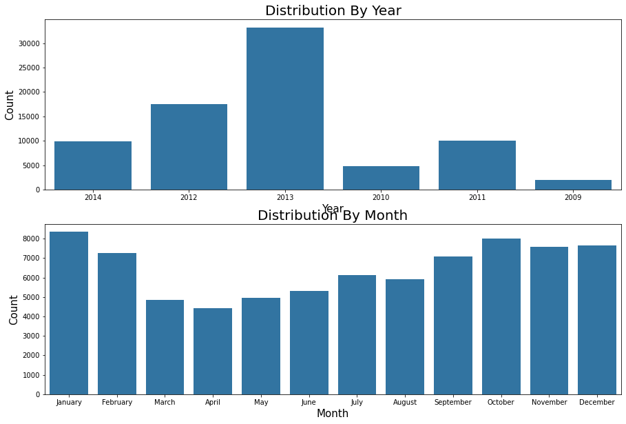

```python
fig, ax = plt.subplots(nrows=2, figsize = [15,10])
default_color = sb.color_palette()[0]
sb.countplot(data = newloan_data, x = 'Year', color = default_color, ax = ax[0])
sb.countplot(data = newloan_data, x = 'Month', color = default_color, ax = ax[1])
ax[0].set_title('Distribution By Year', fontsize = 20)
ax[0].set_xlabel('Year', fontsize = 15)
ax[0].set_ylabel('Count', fontsize = 15)
ax[1].set_title('Distribution By Month', fontsize = 20)
ax[1].set_xlabel('Month', fontsize = 15)
ax[1].set_ylabel('Count', fontsize = 15)
```

### Observation: The year 2013 has the highest loan count. Similarly, January has the highest loan count. Futhermore, the difference in loan count between November, December and February is not significant.

Next step will be to visualize the distribution of the variables of interest.

### Question 2: Which loan status has the highest frequency?

```
LoanStatus
Chargedoff                 4445
Completed                 17690
Current                   51712
Defaulted                   885
FinalPaymentInProgress      187
Past Due (1-15 days)        716
Past Due (16-30 days)       242
Past Due (31-60 days)       325
Past Due (61-90 days)       274
Past Due (91-120 days)      277
Past Due (>120 days)         14
Name: ListingNumber, dtype: int64
```

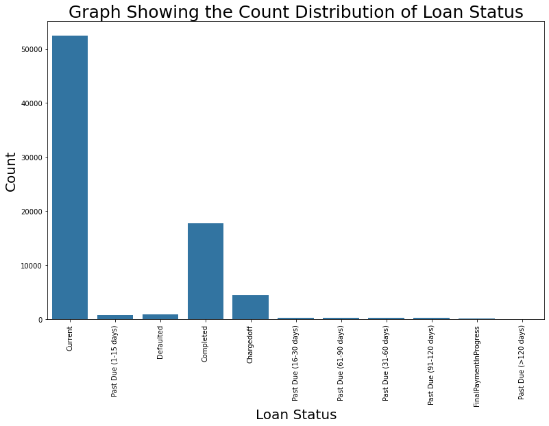

```python
plt.figure(figsize=[13, 8])
base_color = sb.color_palette()[0]
sb.countplot(data=newloan_data, x='LoanStatus', color=base_color);
plt.xticks(rotation=90)
plt.title('Graph Showing the Count Distribution of Loan Status', fontsize = 25)
plt.xlabel('Loan Status', fontsize = 20 );
plt.ylabel('Count', fontsize = 20 )
newloan_data.groupby('LoanStatus')['ListingNumber'].nunique()
```

### Observation: Majority of the loans for the period under consideration (2009 -2014) were still running. The next loan status with high frequency were the completed loans.

### Question 3: What is the distribution of the Borrowers' APR?

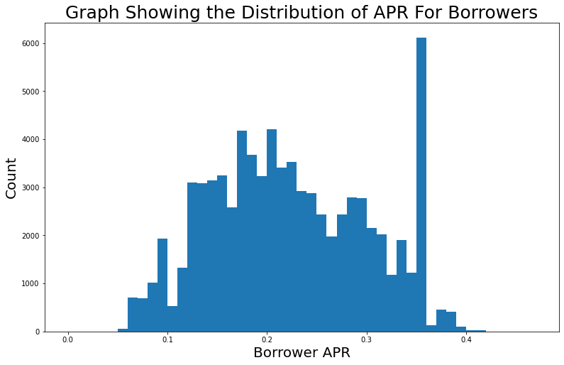

```python
bins = np.arange(0, newloan_data.BorrowerAPR.max()+0.05, 0.01)
plt.figure(figsize=[13,8])
plt.hist(data = newloan_data, x = 'BorrowerAPR', bins = bins);
plt.ylabel('Count', fontsize = 20)
plt.xlabel('Borrower APR', fontsize = 20);
plt.title('Graph Showing the Distribution of APR For Borrowers', fontsize = 25)
```

### Observation: From the output above, it can be seen that the distribution is almost a normal distribution, however, there are several peaks, i.e., the graph is a multimodal with the highest peak found between 0.35 and 0.37

### Question 4: Does Borrowers' Rate follow the same distribution as their APR?

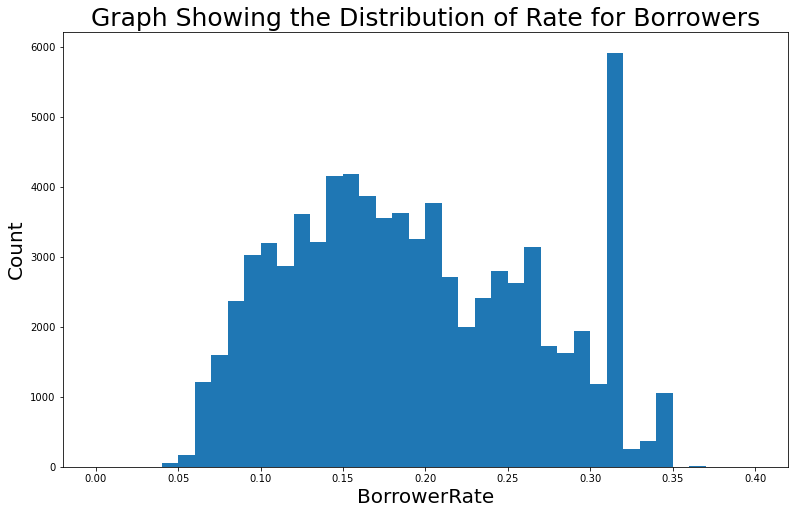

```python
bins = np.arange(0, newloan_data.BorrowerRate.max()+0.05, 0.01)
plt.figure(figsize=[13,8])
plt.hist(data = newloan_data, x = 'BorrowerRate', bins = bins);
plt.ylabel('Count', fontsize = 20)
plt.xlabel('BorrowerRate', fontsize = 20);
plt.title('Graph Showing the Distribution of Rate for Borrowers', fontsize = 25)
```

### Observation: The Rate distribution appears to be almost similar to the APR plot. However, the highest peak for this multimodal graph is between 0.31 and 0.33. Furthermore, beyond the rate of 0.35, the number of loans is infinitesimal.

### Question 5: What is the distribution of the stated monthly income?

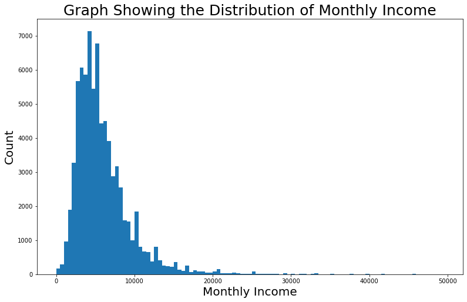

```python
# Distribution of stated monthly income
bin = np.arange(0, 50000, 500)
plt.figure(figsize=[13,8])
plt.hist(data = newloan_data, x = 'StatedMonthlyIncome', bins=bin);
plt.ylabel('Count', fontsize = 20)
plt.xlabel('Monthly Income', fontsize = 20);
plt.title('Graph Showing the Distribution of Monthly Income', fontsize = 25)
```

### Observation: This graph is rightly skewed with the highest number of loan recipients earning close to the mean of approximately 5,964 dollars. Those earning above 15,000 dollars are infinitesimal.

### To properly understand the income distribution, let's look at a graph of the income range. The apriori expectation is that the annual income range would be within the 50,000 dollars mark.

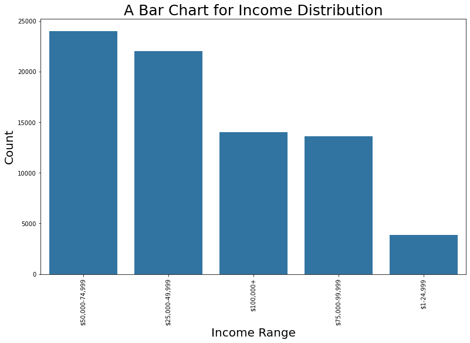

```python
plt.figure(figsize=[13,8])
sb.countplot(data=newloan_data, x='IncomeRange', color=base_color);
plt.xticks(rotation=90)
newloan_data.groupby('IncomeRange')['ListingNumber'].nunique()
plt.title('A Bar Chart for Income Distribution', fontsize = 25)
plt.ylabel('Count', fontsize = 20)
plt.xlabel('Income Range', fontsize = 20);
```

### Question 6: What is the employment status of most of the borrowers?

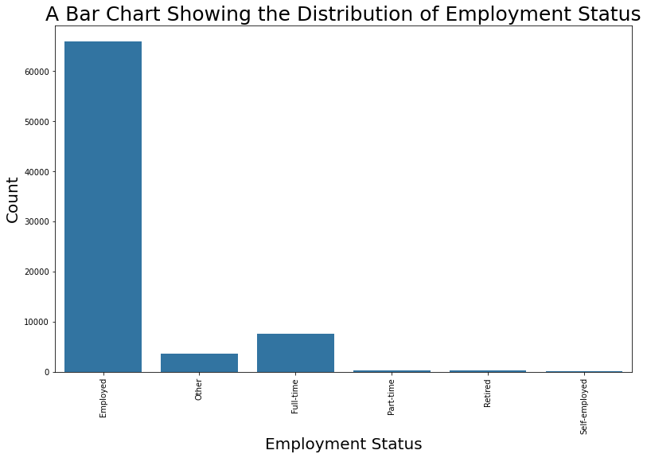

```python
plt.figure(figsize=[13,8])
sb.countplot(data=newloan_data, x='EmploymentStatus', color=base_color);
plt.xticks(rotation=90)
newloan_data.groupby('EmploymentStatus')['ListingNumber'].nunique()
plt.title('A Bar Chart Showing the Distribution of Employment Status', fontsize = 25)
plt.ylabel('Count', fontsize = 20)
plt.xlabel('Employment Status', fontsize = 20);
```

### Observation: Most of the borrowers were employed

### Question 7: What is the distribution of the debt-to-income ratio of the borrowers?

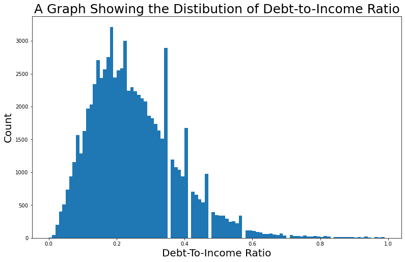

```python
bins = np.arange(0,1, 0.01)
plt.figure(figsize=[13,8])
plt.hist(data = newloan_data, x = 'DebtToIncomeRatio', bins = bins);
plt.xlabel('Debt-To-Income Ratio', fontsize = 20 );
plt.ylabel('Count', fontsize = 20 )
plt.title('A Graph Showing the Distibution of Debt-to-Income Ratio', fontsize = 25)
```

### But let us first view the distribution of the loan amount.

### Question 8: What is the distribution of the loan amount available to the borrowers?

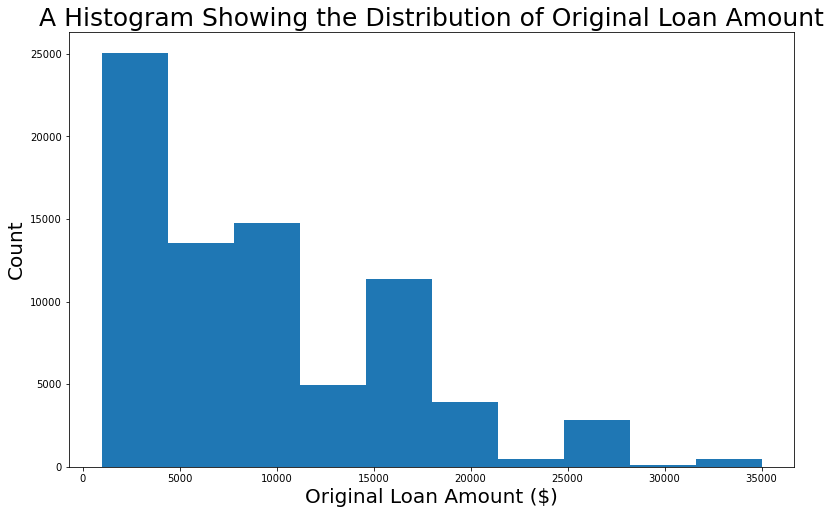

```python
plt.figure(figsize=[13, 8])
plt.hist(newloan_data['LoanOriginalAmount']);
plt.xlabel('Original Loan Amount ($)', fontsize = 20);
plt.ylabel('Count', fontsize = 20);
plt.title('A Histogram Showing the Distribution of Original Loan Amount', fontsize = 25)
```

### Observation: The amount of loan given to most of the borrowers was lower than the mean value of approximately 9,270 dollars, with the highest amount falling between 2k to 5k dollars.

### Question 9: What is the distribution of Prosper Score?

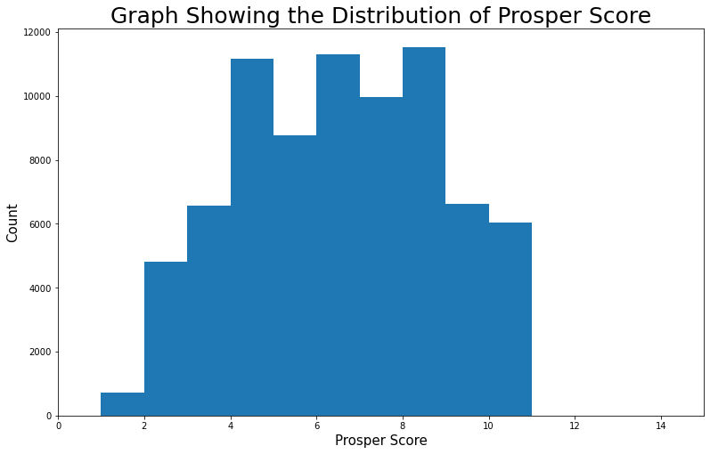

```python
bin = np.arange(0, 12, 1)
plt.figure(figsize=[13,8])
plt.hist(data = newloan_data, x = 'ProsperScore', bins = bin);
plt.ylabel('Count', fontsize = 15)
plt.xlabel('Prosper Score', fontsize = 15);
plt.xlim(0, 15)
plt.title('Graph Showing the Distribution of Prosper Score', fontsize = 25)
```

### Observation: The graph is almost normally distributed but multimodal with the highest number of borrowers falling between a prosper score of 8 and 9.

### Question 10: What is the distribution of loan terms among the borrowers?

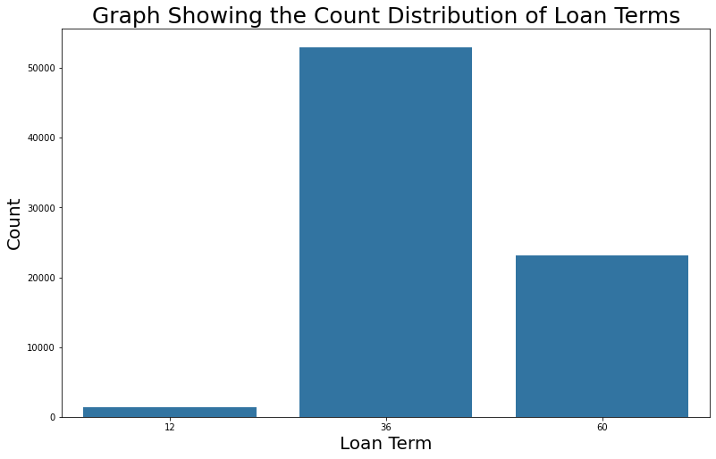

```python
plt.figure(figsize=[13, 8])
base_color = sb.color_palette()[0]
sb.countplot(data=newloan_data, x='Term', color=base_color);
plt.title('Graph Showing the Count Distribution of Loan Terms', fontsize = 25)
plt.xlabel('Loan Term', fontsize = 20 );
plt.ylabel('Count', fontsize = 20 )
```

### Observation: The most availed loan term was 36 months. It will be intersting to see how this would affect loan status or APR

### Discuss the distribution(s) of your variable(s) of interest. Were there any unusual points? Did you need to perform any transformations?

> There was no need to perform any transformation. APR had no unusual points, liokewise the other variables. Furthermore, both APR and borrower Rate had almost similar distribution. In terms of skewness, monthly income as well as DTI were rightly skewed.

### Of the features you investigated, were there any unusual distributions? Did you perform any operations on the data to tidy, adjust, or change the form of the data? If so, why did you do this?

> No tidying, adjustment or change was done to any of the variables of interest.

## Bivariate Exploration

> In this section, I will be investigating the relationships between pairs of my variables in my data.

Firstly, I will exploring the relationship between all numeriacl variables of interest using a heat map. The result would inform further investigation.

### Question 1: What is the relationship between the numerical variables of interest?

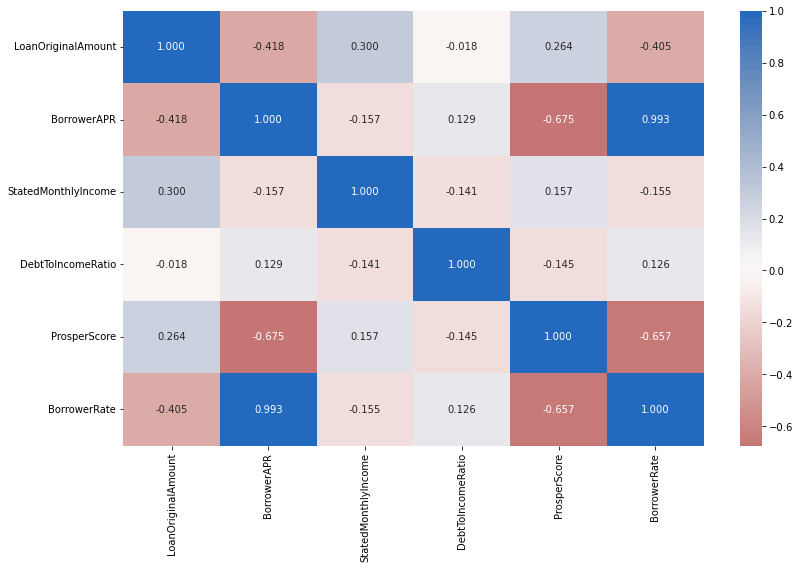

```python
numerical_variables = ['LoanOriginalAmount', 'BorrowerAPR', 'StatedMonthlyIncome','DebtToIncomeRatio', 'ProsperScore', 'BorrowerRate']
plt.figure(figsize = [13, 8])
sb.heatmap(newloan_data[numerical_variables].corr(), annot = True, fmt = '.3f',
           cmap = 'vlag_r', center = 0);
```

### Observation: Some interesting relationships stand out from the above correlation plot. BorrowerAPR vs BorrowerRate (corr = 0.993), BorrowerAPR vs ProsperScore (corr = -0.675), BorrowerAPR vs LoanOriginalAmount (-0.418). Negative sign connotes an inverse relationship between the two variables.

To have a good picture of this relationship, I will be expressing these realtionships using a regression plot.

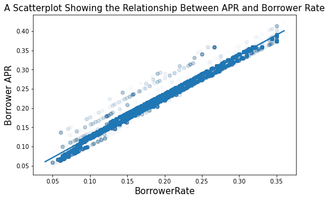

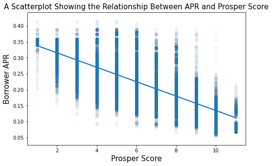

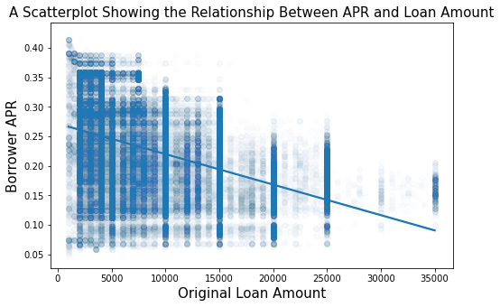

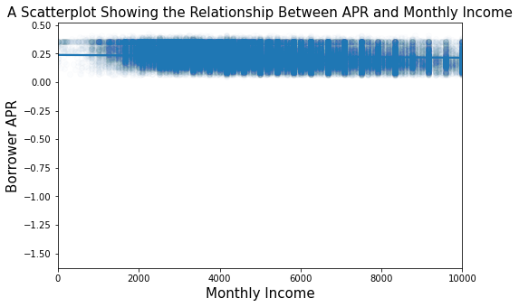

```python
plt.figure(figsize = [8,5])
sb.regplot(data = newloan_data, x = 'BorrowerRate', y = 'BorrowerAPR', scatter_kws={'alpha':0.01});
plt.xlabel('BorrowerRate', fontsize = 15);
plt.ylabel('Borrower APR', fontsize = 15);
plt.title('A Scatterplot Showing the Relationship Between APR and Borrower Rate', fontsize = 15)

plt.figure(figsize = [8,5])
sb.regplot(data = newloan_data, x = 'ProsperScore', y = 'BorrowerAPR', scatter_kws={'alpha':0.01});
plt.xlabel('Prosper Score', fontsize = 15);
plt.ylabel('Borrower APR', fontsize = 15);
plt.title('A Scatterplot Showing the Relationship Between APR and Prosper Score', fontsize = 15)

plt.figure(figsize = [8,5])
sb.regplot(data = newloan_data, x = 'LoanOriginalAmount', y = 'BorrowerAPR', scatter_kws={'alpha':0.01});
plt.xlabel('Original Loan Amount', fontsize = 15);
plt.ylabel('Borrower APR', fontsize = 15);
plt.title('A Scatterplot Showing the Relationship Between APR and Loan Amount', fontsize = 15)

plt.figure(figsize = [8,5])
sb.regplot(data = newloan_data, x = 'StatedMonthlyIncome', y = 'BorrowerAPR', scatter_kws={'alpha':0.01});
plt.xlim(0, 10000)
plt.xlabel('Monthly Income', fontsize = 15);
plt.ylabel('Borrower APR', fontsize = 15);
plt.title('A Scatterplot Showing the Relationship Between APR and Monthly Income', fontsize = 15)

plt.show()
```

### Observation: The above figures displays the result of the correlation analysis. The BorrowerAPR vs StatedMonthlyIncome was included among these figures as a way of confirming the negative but weak association (corr = -0.157) shown from the heat map.

Next step will be to explore the association between our categorical variable of interest (Loan Status) and other variables

### Question 2: Is there a relationship between Loan Status and the Original Loan Amount?

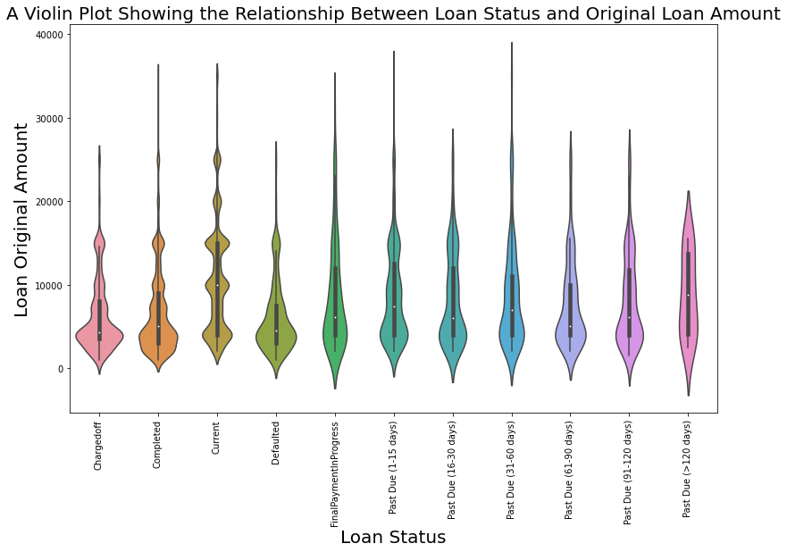

```python
Loan_status = ['Chargedoff', 'Completed', 'Current', 'Defaulted', 'FinalPaymentInProgress', 'Past Due (1-15 days)', 'Past Due (16-30 days)',
              'Past Due (31-60 days)', 'Past Due (61-90 days)', 'Past Due (91-120 days)', 'Past Due (>120 days)']
Loanstat = pd.api.types.CategoricalDtype(ordered=True, categories=Loan_status)
newloan_data['LoanStatus'] = newloan_data['LoanStatus'].astype(Loanstat);
plt.figure(figsize=[13, 8])
sb.violinplot(data=newloan_data, x='LoanStatus', y='LoanOriginalAmount');
plt.xticks(rotation=90)
plt.xlabel('Loan Status', fontsize = 20);
plt.ylabel('Loan Original Amount', fontsize = 20);
plt.title('A Violin Plot Showing the Relationship Between Loan Status and Original Loan Amount', fontsize = 20)
```

### It would be insightful to explore the role of income in the ability of the borrowers to complete payment.

### Question 3: What is the relationship between monthly income and loan status?

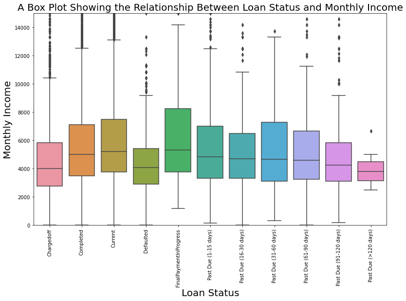

```python
plt.figure(figsize=[13, 8])
sb.boxplot(data=newloan_data, x='LoanStatus', y='StatedMonthlyIncome');
plt.xticks(rotation=90)
plt.ylim(0, 15000)
plt.xlabel('Loan Status', fontsize = 20);
plt.ylabel('Monthly Income', fontsize = 20);
plt.title('A Box Plot Showing the Relationship Between Loan Status and Monthly Income', fontsize = 20)
```

### Observation: The mean income for completed current and payment in progress loans is higher than all other forms of bad or defaulting loans. This explains the role of income in ability to pay down on loans.

Next I want to explore the realtionship between loan status and borrowers' rate. The apriori expectation is that higher rate discourages payment, so we expect those who have completed, currently on or about to complete their payment to have a lower borrower's rate.

### Question 4: What is the relationship between loan status and borrower rate?

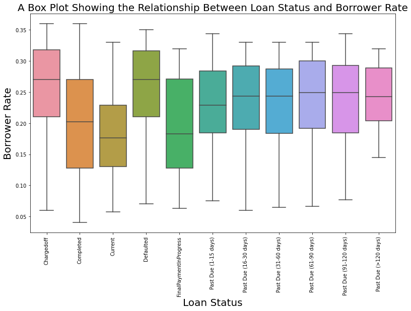

```python
plt.figure(figsize=[13, 8])
sb.boxplot(data=newloan_data, x='LoanStatus', y='BorrowerRate');
plt.xticks(rotation=90)
plt.xlabel('Loan Status', fontsize = 20);
plt.ylabel('Borrower Rate', fontsize = 20);
plt.title('A Box Plot Showing the Relationship Between Loan Status and Borrower Rate', fontsize = 20)
```

## Multivariate Exploration

### Question 1: Does the relationship between APR and Loan Amount vary with Loan Term?

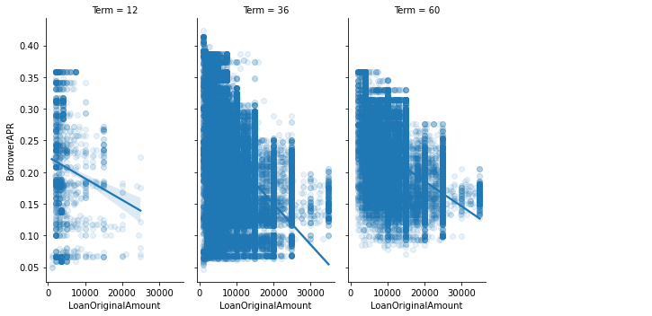

```python
g=sb.FacetGrid(data = newloan_data, aspect=0.5, height=5, col='Term', col_wrap=4)
g.map(sb.regplot, 'LoanOriginalAmount', 'BorrowerAPR', x_jitter=0.04, scatter_kws={'alpha':0.1});
g.add_legend();
```

### Observation: Across all loan tenures (12, 36 and 60 months) the relationship between APR and Original Loan Amount remained unchanged, i.e., a negative relationship was still observed.

### Question 2: How does the relationship between APR and loan status vary with loan term?

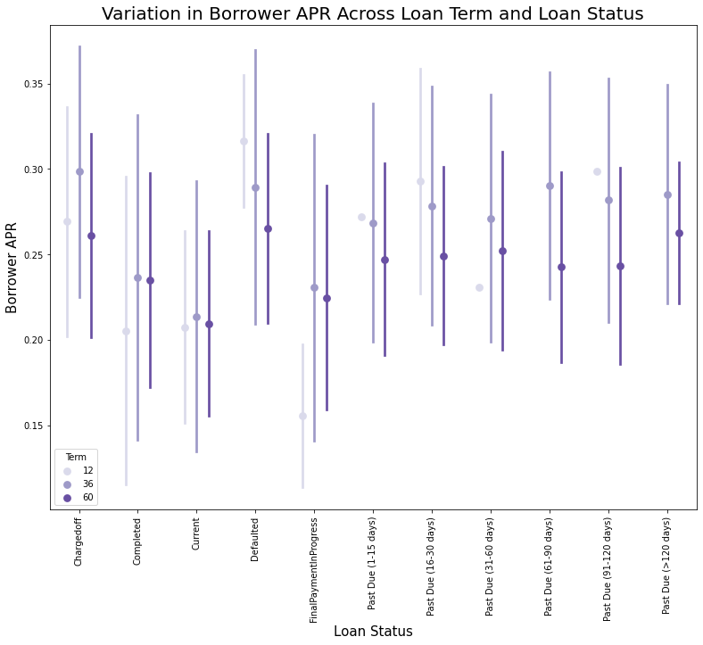

```python
fig = plt.figure(figsize = [13,10])
ax = sb.pointplot(data = newloan_data, x = 'LoanStatus', y = 'BorrowerAPR', hue = 'Term',
           palette = 'Purples', linestyles = '', dodge = 0.4, ci='sd')
plt.title('Variation in Borrower APR Across Loan Term and Loan Status', fontsize = 20)
plt.xlabel('Loan Status', fontsize = 15)
plt.ylabel('Borrower APR', fontsize = 15)
ax.set_yticklabels([],minor = True);
plt.xticks(rotation = 90);
```

### Question 3: How does the relationship between APR and prosper score vary with loan term?

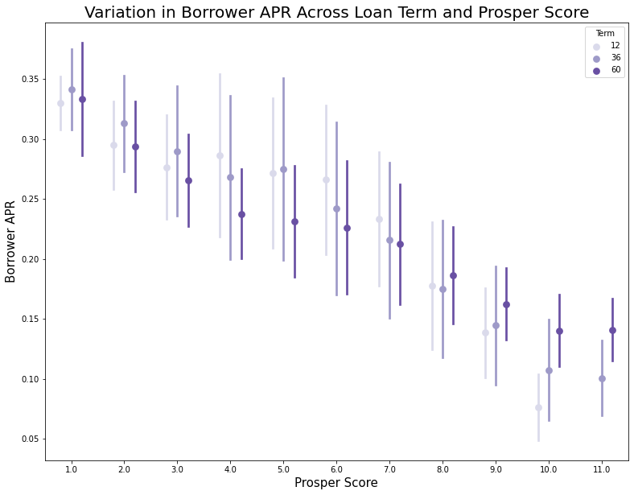

```python
fig = plt.figure(figsize = [13,10])
ax = sb.pointplot(data = newloan_data, x = 'ProsperScore', y = 'BorrowerAPR', hue = 'Term',
           palette = 'Purples', linestyles = '', dodge = 0.4, ci='sd')
plt.title('Variation in Borrower APR Across Loan Term and Prosper Score', fontsize = 20)
plt.xlabel('Prosper Score', fontsize = 15)
plt.ylabel('Borrower APR', fontsize = 15)
ax.set_yticklabels([],minor = True);
```

### Observation: Three patterns can be observed from this plot. Between the score of 1 and 3, an increase was first observed, followed by a decrease in APR as the loan term increased. Score 4, 6 and 7 showed a decreasing APR with an increase in loan term while score 9 - 11 revealed an increase in APR with increase in loan term.

### Talk about some of the relationships you observed in this part of the investigation. Were there features that strengthened each other in terms of looking at your feature(s) of interest?

> The relationship between APR and Loan Status was strengthened by loan term. Especially as it affects defaulters and past due obligations. Usually, lenders would want to carry out restructuring of loans for defaulters to help them pay down and this could be in the form of extending the term, reducing the interest rate or both. This graph clearly explains the principle of loan restructuring, where extended terms are given to defaulters alongside a reduction in APR to enable them pay down on these loans.

### Were there any interesting or surprising interactions between features?

> No consistent pattern was observed in the relationship between APR and Prosper Score in the presence of loan Term.

## Conclusions

> This visualization process has revealed an interesting relationship between people's ability to complete their loan repayment and other factors. The main predictors of loan status as investigated were loan amount, monthly income and rate. Furthermore, I explored how factors like loan amount, monthly income and prosper score (which measures credit worthiness) affects borrower's annual percentage rate (APR). As a way to further understad relationships, a mediation effect was conducted on these relationships using loan tenure (Term) as a mediator.

> The steps undertaken in this visualization include: Data gathering, Data assessing, Data cleaning, Univariate exploration, Bivariate exploration and Multivariate exploration

Finally, I will be saving the cleaned dataset

```python
newloan_data.to_csv('cleanedloan_data.csv')
```